# Anova

26 février 2026

## Anova à 1 facteur

## Intuition

Les cèdres sont-ils plus haut que les pins ?

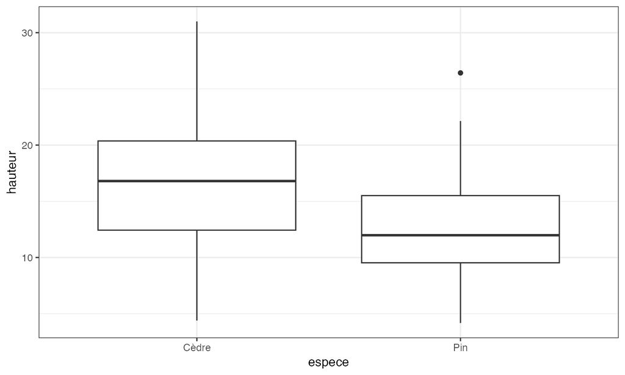

```r
ventoux |>
  ggplot(aes(x = espece, y = hauteur)) +
  geom_boxplot()
```

## Théorie

Modèle de régression avec des covariables toutes catégorielles, codées sous forme d’indicatrices (autant d’indicatrices que de modalités - 1).

Exemple du Ventoux :

\[Y = \beta_0 + \beta_1 \mathbb{1}('Cedre') + \Epsilon\]

Ici, deux modalités seulement \(\to\) quelle autre méthode utiliser ?

L’Anova à un facteur étend le test de Student à plus de deux groupes, comme le test de Welch (`oneway.test()`), non traité ici.

## `aov()`

```r
aov(hauteur ~ espece, data = ventoux) %>% {. ->> ventoux_aov} |> summary()
```

```
##              Df Sum Sq Mean Sq F value  Pr(>F)
## espece        1    824   823.6    33.1 2.9e-08
## Residuals   221   5499    24.9
##
## espece      ***
## Residuals
## ---
## Signif. codes:
## 0 '***' 0.001 '**' 0.01 '*' 0.05 '.' 0.1 ' ' 1
```

La hauteur des arbres est différente entre les espèces.

La statistique de test est le rapport entre les sommes des carrés des écarts intergroupe et intragroupe, divisés par leurs degrés de liberté, qui suit une loi de Fisher (F).

## Hypothèses

Celles du modèle linéaire.

- Homoscédasticité : la variance de l’erreur est identique entre les groupes.

## Homoscédasticité

Graphique \(\Epsilon \sim Y^\star\)

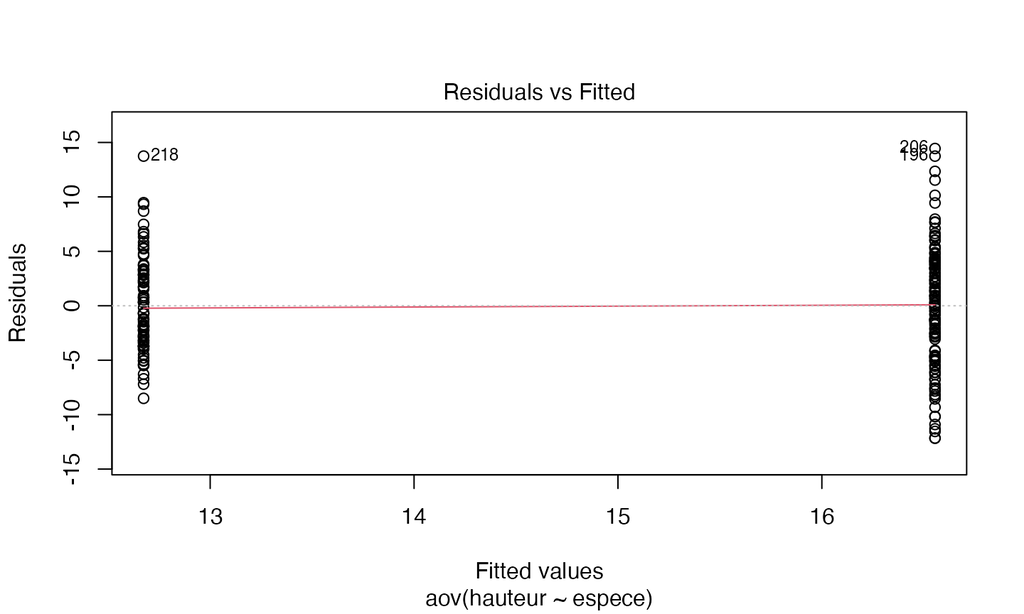

```r
plot(ventoux_aov, which = 1)
```

Les erreurs doivent être centrée sur 0 et uniformément réparties.

## Homoscédasticité

Le test de Levene invalide l’hypothèse nulle d’égalité des variances.

```r
library("car")
with(ventoux, leveneTest(hauteur ~ espece))
```

```
## Levene's Test for Homogeneity of Variance (center = median)
##        Df F value   Pr(>F)
## group   1  6.7887 0.009797 **
##       221
## ---
## Signif. codes:
## 0 '***' 0.001 '**' 0.01 '*' 0.05 '.' 0.1 ' ' 1
```

## Anova non paramétrique

Il faut utiliser le test de Kruskal-Wallis, qui est un modèle linéaire sur les rangs.

```r
kruskal.test(hauteur ~ espece, data = ventoux)
```

```
##
##  Kruskal-Wallis rank sum test
##
## data:  hauteur by espece
## Kruskal-Wallis chi-squared = 31.337, df = 1,
## p-value = 2.169e-08
```

## Tests post-hoc

## Manchots

Exemple [traité en détail](https://statsandr.com/blog/anova-in-r/) par Antoine Soetewey.

Les données sont les longueurs des nageoires de trois espèces de manchots.

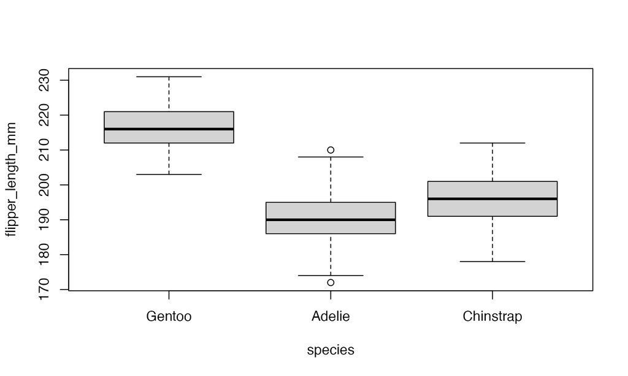

```r
library("palmerpenguins")
with(penguins, boxplot(flipper_length_mm ~ species))
```

## Anova

```r
aov(flipper_length_mm ~ species, data = penguins) %>%
  {. ->> penguins_aov} |>
  summary()
```

```
##              Df Sum Sq Mean Sq F value Pr(>F)
## species       2  52473   26237   594.8 <2e-16 ***
## Residuals   339  14953      44
## ---
## Signif. codes:
## 0 '***' 0.001 '**' 0.01 '*' 0.05 '.' 0.1 ' ' 1
## 2 observations deleted due to missingness
```

\(\to\) Vérifiez le respect des hypothèses

Les trois espèces n’ont pas toutes les mêmes longueur de nageoires… Mais encore ? \(\to\) Tests post-hoc.

## Tests de Tukey

Le test de Tukey compare tous les groupes deux à deux.

```r
library("multcomp")
penguins_aov |> glht(linfct = mcp(species = "Tukey")) %>%
  {. ->> penguins_tukey} |> summary()
```

```
##
##   Simultaneous Tests for General Linear Hypotheses
##
## Multiple Comparisons of Means: Tukey Contrasts
##
##
## Fit: aov(formula = flipper_length_mm ~ species, data = penguins)
##
## Linear Hypotheses:
##                         Estimate Std. Error
## Adelie - Gentoo == 0    -27.2333     0.8067
## Chinstrap - Gentoo == 0 -21.3635     1.0036
## Chinstrap - Adelie == 0   5.8699     0.9699
##                         t value Pr(>|t|)
## Adelie - Gentoo == 0    -33.760   <1e-08 ***
## Chinstrap - Gentoo == 0 -21.286   <1e-08 ***
## Chinstrap - Adelie == 0   6.052   <1e-08 ***
## ---
## Signif. codes:
## 0 '***' 0.001 '**' 0.01 '*' 0.05 '.' 0.1 ' ' 1
## (Adjusted p values reported -- single-step method)
```

## Le problème des tests multiples

Le seuil de risque de 5% signifie que 5% des tests seront des faux positifs.

Avec 7 groupes, on fait \(6 \times 7 / 2 = 21\) tests d’égalité, donc on attend un faux positif.

Le risque de rejeter au moins une fois l’hypothèse nulle est \[1 - (1 - \alpha)^n \approx n\alpha\] Solution : réduire le seuil de risque \(\alpha_m\) (pour *multiple*) : \[\alpha_m = \alpha / n\] C’est la correction de *Bonferroni*.

## Test de Dunnett

Si un groupe est la référence (par exemple, le témoin), utiliser le test de Dunnett, plus puissant.

Le groupe de référence est le premier des facteurs.

```r
str(penguins$species)
```

```
##  Factor w/ 3 levels "Gentoo","Adelie",..: 2 2 2 2 2 2 2 2 2 2 ...
```

Il peut être modifié :

```r
penguins$species <- relevel(penguins$species, ref = "Gentoo")
str(penguins$species)
```

```
##  Factor w/ 3 levels "Gentoo","Adelie",..: 2 2 2 2 2 2 2 2 2 2 ...
```

## Graphiques

Objectif : ajouter les informations de l’Anova aux boîtes à moustache.

Avec *ggstatsplot* :

```r
library("ggstatsplot")
penguins |>
  ggbetweenstats(
    x = species,
    y = flipper_length_mm,
    type = "parametric", # ANOVA or Kruskal-Wallis
    var.equal = TRUE, # ANOVA or Welch ANOVA
    plot.type = "box",
    pairwise.comparisons = TRUE,
    pairwise.display = "significant",
    centrality.plotting = FALSE,
    bf.message = FALSE
  )
```

## Graphiques

*ggstatsplot* :

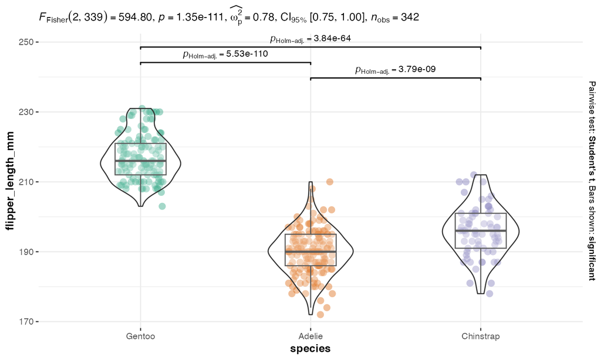

## Graphiques

Graphique plus sobre, selon [Rosane Rech](https://statdoe.com/one-way-anova-and-box-plot-in-r/).

Les groupes identiques sont habituellement marqués par des lettres.

```r
# Test de Tukey du package stats (moins détaillé que celui de multcomp)
penguins_tukey <- TukeyHSD(penguins_aov)
library("multcompView")
(penguins_letters <- multcompLetters4(penguins_aov, penguins_tukey))
```

```
## $species
##    Gentoo Chinstrap    Adelie
##       "a"       "b"       "c"
```

```r
# Préparation d'un tibble contenant les lettres (format compliqué)
penguins_letters_tb <- tibble(
  species = names(penguins_letters[[1]]$Letters),
  letter = as.character(penguins_letters[[1]]$Letters)
)
```

## Graphiques

Un tableau avec les groupes, leur lettre et leur 75ème centile est nécessaire pour la figure :

```r
penguins |>
  group_by(species) %>%
  summarise(q_75 = quantile(flipper_length_mm, probs = 0.75, na.rm = TRUE)) |>
  inner_join(penguins_letters_tb) -> penguins_letters_tbq
```

```r
# Graphique
ggplot() +
  geom_boxplot(
    data = penguins,
    aes(x = species, y = flipper_length_mm, fill = species),
    show.legend = FALSE
  ) +
  geom_text(
    data = penguins_letters_tbq,
    aes(x = species, y = q_75, label = letter),
    size = 5, vjust=-1, hjust =-1
  ) +
  scale_fill_brewer(palette = "Blues")
```

## Graphiques

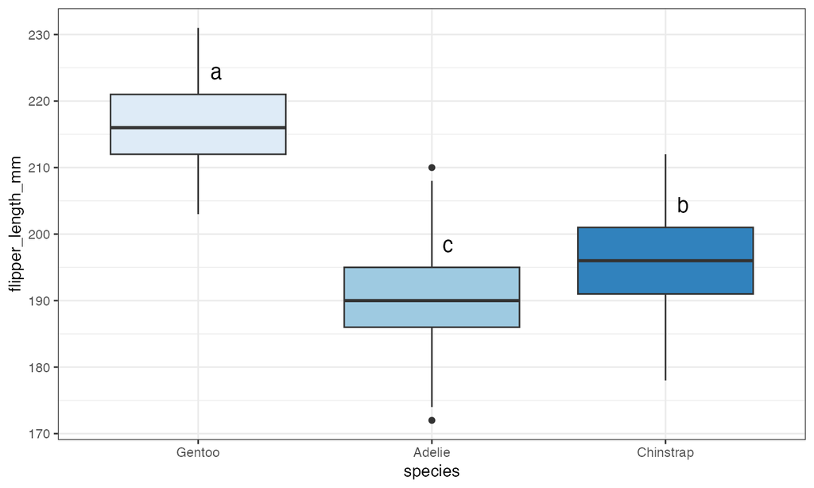